# ~ Comparison between kernelized and non-kernelized methods for classification of diabetes patients ~

Silje Marie Anfindsen & Jonathan Stålberg

5/5/2021

Apply an standard kernel method (SVM, kRR, kPCA, …) to a specific problem of your interest, with comparison to other approaches. The focus is on the application

# Introduction

# Discussion

#Conclusion and future work

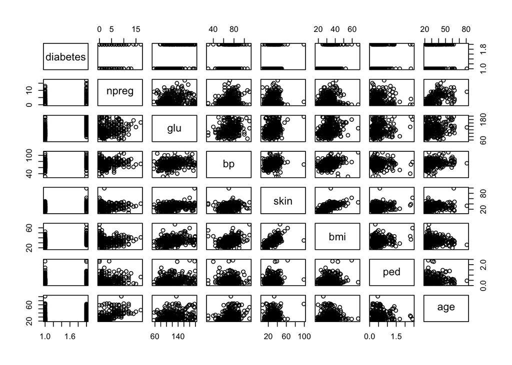

```r
id <- "1Fv6xwKLSZHldRAC1MrcK2mzdOYnbgv0E"  # google file ID
d.diabetes <- dget(sprintf("https://docs.google.com/uc?id=%s&export=download",
    id))
d.train = d.diabetes$ctrain
d.test = d.diabetes$ctest

#make diabetes a factor variable
d.train$diabetes <- as.factor(d.train$diabetes)
d.test$diabetes <- as.factor(d.test$diabetes)

plot(d.train)
```

```r
set.seed(10111)
start_time <- Sys.time()

#10-fold CV to test model fit svm radial boundary with different parameters
cv.radial <- tune(svm, diabetes ~., data = d.train, kernel = "radial",
                  ranges = list(cost = c(0.1,1,10,100,1000), gamma = c(0.5,1,2,3,4) ))
end_time <- Sys.time()
end_time - start_time
```

```
## Time difference of 2.713692 secs
```

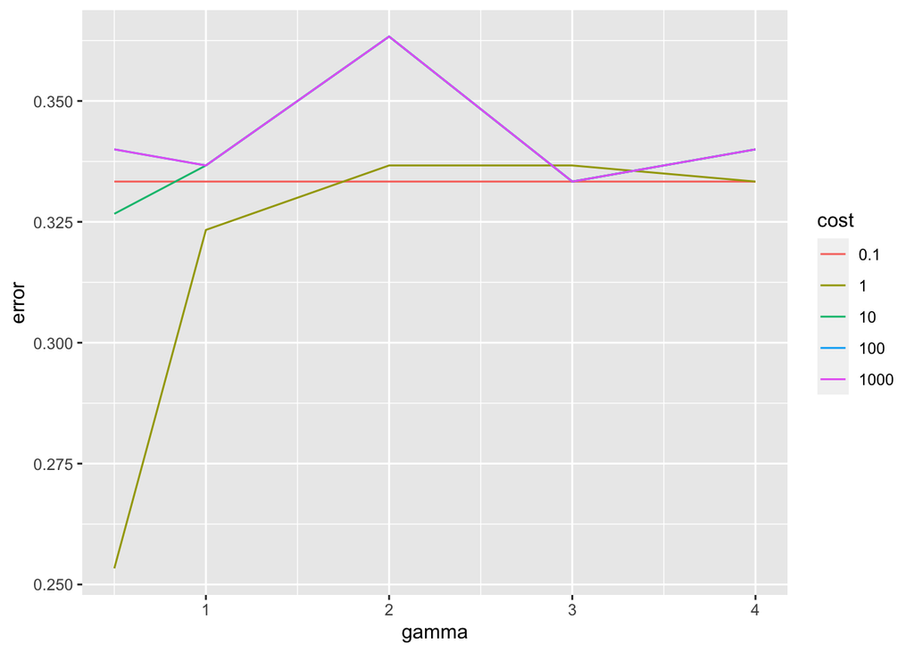

```r
#plot different values for the two hyperparameters
svm.performance <- cv.radial$performances
svm.performance$cost <- as.factor(svm.performance$cost)
ggplot(svm.performance, aes(x=gamma,y=error, color=cost)) +
  geom_line()
```

```r
#ggpairs(d.train, aes(colour = diabetes, alpha = 0.4))

#fit new models with the optimalized parameters from CV
bestmod.radial = cv.radial$best.model

# Predict the response for the test set
pred.rad = predict(bestmod.radial, newdata = d.test)

# Confusion tables (0: no diabetes, 1: diabetes)
t <- table(Prediction = pred.rad, Truth = d.test$diabetes)
t
```

```
##           Truth
## Prediction   0   1
##          0 133  38
##          1  22  39
```

```r
#can calculate sensitivity and specificity later
svm_acc <- 100 * sum(d.test$diabetes == pred.rad)/NROW(d.test$diabetes)
svm_acc
```

```
## [1] 74.13793
```

```r
#fit a logistic regression model using training data
start_time <- Sys.time()

glm.fit <- glm(diabetes ~ .,data=d.train, family="binomial") #predict the response using testing data
end_time <- Sys.time()
end_time - start_time
```

```
## Time difference of 0.00623107 secs
```

```r
glm.probs <- predict(glm.fit, newdata=d.test, type="response")

#sort the probabilities for whether the observations are < or > than p = 0.5
glm.pred = rep("0",length(d.test$diabetes))
#create vector of nr. of elements = dataset
glm.pred[glm.probs>0.5]="1"
#confusion table
table(Prediction = glm.pred, Truth = d.test$diabetes)
```

```
##           Truth
## Prediction   0   1
##          0 136  32
##          1  19  45
```

```r
glm_ACC <- 100 * sum(d.test$diabetes == glm.pred)/NROW(d.test$diabetes)
glm_ACC
```

```
## [1] 78.01724
```

In logistic regression all observations contribute to the decision boundary, while for SVMs, only the support vectors (the points closest to the decision boundary) contribute to the margin. A consequence of this is that LR is more sensitive to outliers than SVM. For classes that are well separeted SVM tend to perform better than LR, while in more overlapping regimes we usually prefer LR. We also know that logistic regression produces probabilistic values, while SVM produces binary values. This can be an advantage if we want an estimation rather than just the resulting class for each observation.

```r
start_time <- Sys.time()
cv.knn <- tune.knn(y=d.train$diabetes,x=d.train[,2:8], data = d.train,k = 1:100, tunecontrol=tune.control(sampling="cross"), cross=10 )
end_time <- Sys.time()
end_time - start_time
```

```
## Time difference of 1.440312 secs
```

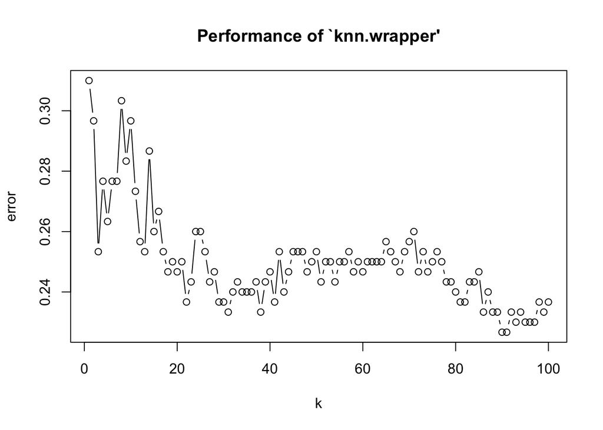

```r
plot(cv.knn)
```

```r
cv.knn$best.parameters
```

```
##     k
## 90 90
```

```r
knn.fit <- cv.knn$best.model

#Summarize the resampling results set
pred.knn <- knn(train=d.train, test=d.test,cl=d.train$diabetes, k=cv.knn$best.parameters)

# Confusion tables (0: no diabetes, 1: diabetes)
table(Prediction = pred.knn, Truth = d.test$diabetes)
```

```
##           Truth
## Prediction   0   1
##          0 146  41
##          1   9  36
```

```r
knn_ACC <- 100 * sum(d.test$diabetes == pred.knn)/NROW(d.test$diabetes)
knn_ACC
```

```
## [1] 78.44828
```

```r
#randomforest
rf.diabetes = randomForest(diabetes ~ ., data = d.train)
pred.rf= predict(rf.diabetes, newdata=d.test)
rf_table <- table(prediction=pred.rf, Truth=d.test$diabetes)
rf_ACC <- 100 * sum(d.test$diabetes == pred.rf)/NROW(d.test$diabetes)
```

```r
control <- trainControl(method="repeatedcv", number=10, repeats=3)
# CART
set.seed(7)
fit.cart <- train(diabetes~., data=d.train, method="rpart", trControl=control)
# LDA
set.seed(7)
fit.lda <- train(diabetes~., data=d.train, method="lda", trControl=control)
# SVM
set.seed(7)
fit.svm <- train(diabetes~., data=d.train, method="svmRadial", trControl=control)
# kNN
set.seed(7)
fit.knn <- train(diabetes~., data=d.train, method="knn", trControl=control)
# Random Forest
set.seed(7)
fit.rf <- train(diabetes~., data=d.train, method="rf", trControl=control)
# collect resamples
results <- resamples(list(CART=fit.cart, LDA=fit.lda, SVM=fit.svm, KNN=fit.knn, RF=fit.rf))
```

```r
# summarize differences between modes
summary(results)
```

```
##
## Call:
## summary.resamples(object = results)
##
## Models: CART, LDA, SVM, KNN, RF
## Number of resamples: 30
##
## Accuracy
##           Min.   1st Qu.    Median      Mean   3rd Qu.      Max. NA's
## CART 0.5333333 0.6750000 0.7666667 0.7422222 0.7916667 0.9333333    0
## LDA  0.6333333 0.7416667 0.8000000 0.7922222 0.8333333 0.9666667    0
## SVM  0.6000000 0.7416667 0.7833333 0.7822222 0.8333333 0.9333333    0
## KNN  0.6000000 0.7000000 0.7500000 0.7455556 0.7916667 0.8666667    0
## RF   0.6000000 0.7083333 0.7666667 0.7777778 0.8333333 0.9333333    0
##
## Kappa
##            Min.   1st Qu.    Median      Mean   3rd Qu.      Max. NA's
## CART -0.1142857 0.2419862 0.3842105 0.3784376 0.5166881 0.8500000    0
## LDA   0.1081081 0.3834586 0.5131579 0.5065256 0.6101871 0.9268293    0
## SVM   0.0000000 0.3763158 0.4939024 0.4868290 0.6101871 0.8500000    0
## KNN   0.0000000 0.2702703 0.3842105 0.3916194 0.5101215 0.7000000    0
## RF    0.1000000 0.2948080 0.4660633 0.4778536 0.6153846 0.8500000    0
```

This is a useful way to look at the spread of the estimated accuracies for different methods and how they relate

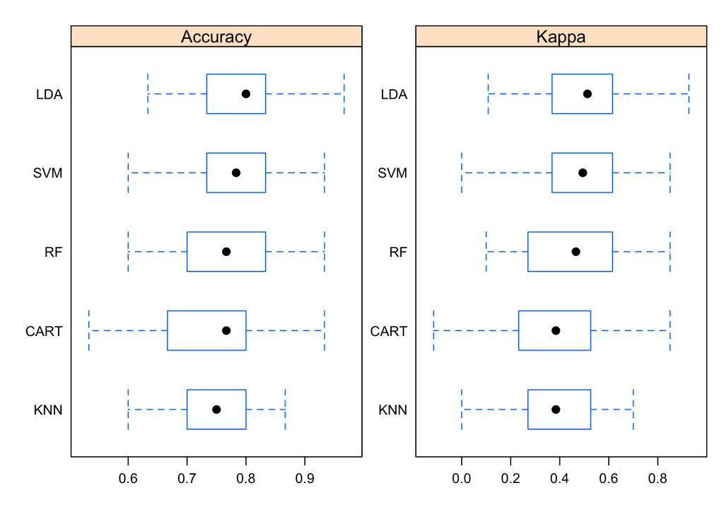

```r
# box and whisker plots to compare models
scales <- list(x=list(relation="free"), y=list(relation="free"))
bwplot(results, scales=scales)
```

DENSITY PLOTS You can show the distribution of model accuracy as density plots. This is a useful way to evaluate the overlap in the estimated behavior of algorithms.

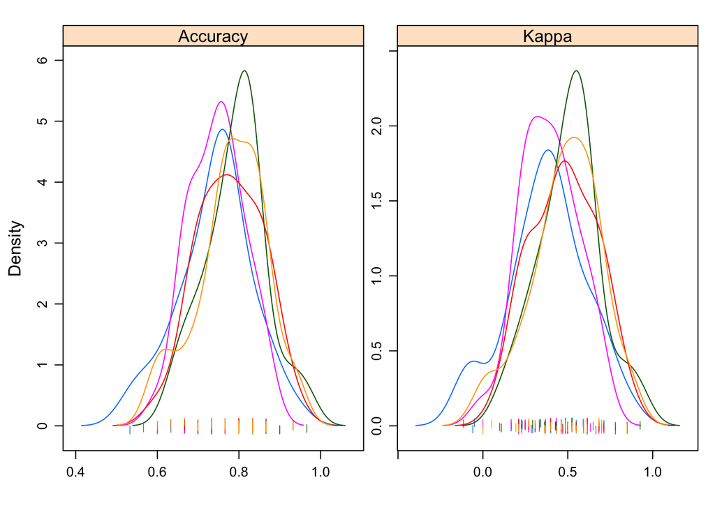

```r
# density plots of accuracy
scales <- list(x=list(relation="free"), y=list(relation="free"))
densityplot(results, scales=scales, pch = "|")
```

I like to look at the differences in the peaks as well as the spread or base of the distributions.

```r
# difference in model predictions
diffs <- diff(results)
# summarize p-values for pair-wise comparisons
summary(diffs)
```

```
##
## Call:
## summary.diff.resamples(object = diffs)
##
## p-value adjustment: bonferroni
## Upper diagonal: estimates of the difference
## Lower diagonal: p-value for H0: difference = 0
##
## Accuracy
##      CART      LDA       SVM       KNN       RF
## CART           -0.050000 -0.040000 -0.003333 -0.035556
## LDA  0.0006226            0.010000  0.046667  0.014444
## SVM  0.0068833 1.0000000            0.036667  0.004444
## KNN  1.0000000 0.0014444 0.0864365           -0.032222
## RF   0.0320732 1.0000000 1.0000000 0.1552755
##
## Kappa
##      CART      LDA       SVM       KNN       RF
## CART           -0.128088 -0.108391 -0.013182 -0.099416
## LDA  0.0003785            0.019697  0.114906  0.028672
## SVM  0.0023060 1.0000000            0.095210  0.008975
## KNN  1.0000000 0.0005045 0.0298831           -0.086234
## RF   0.0318556 1.0000000 1.0000000 0.0617048
```

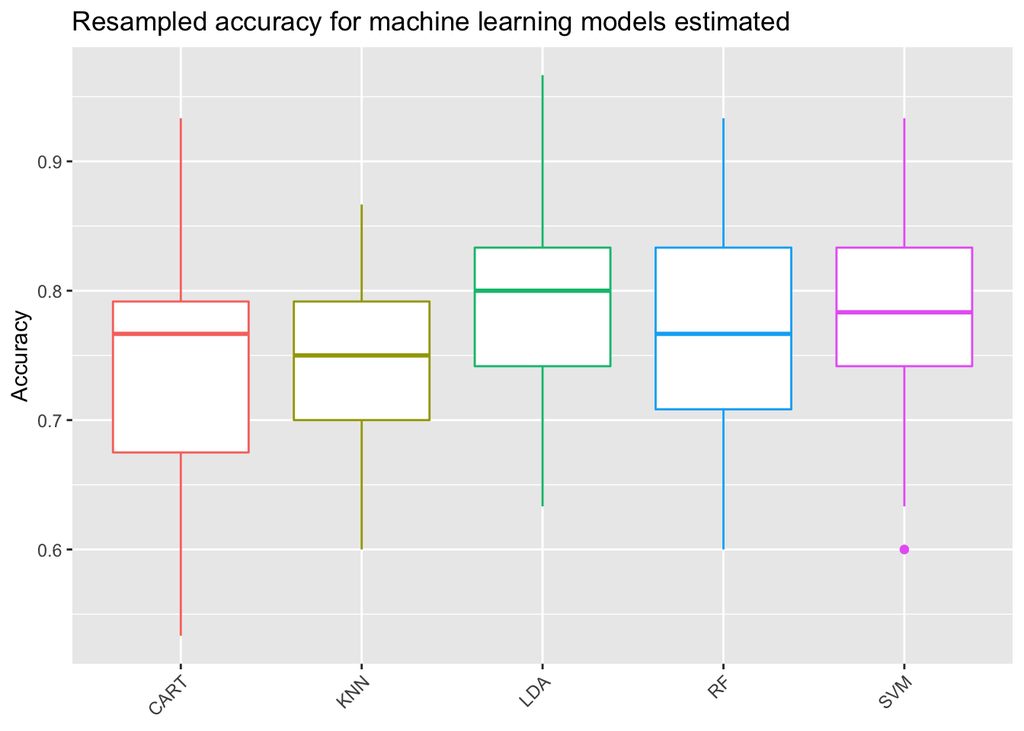

```r
accuracy_variables = names(results$values)[grepl("Accuracy", names(results$values))]
plotdf = melt(results$values[, c('Resample', accuracy_variables)],
              id = "Resample", value.name = "Accuracy", variable.name = "Model")
plotdf$Model = gsub("~.*","", plotdf$Model)

ggplot() +
  geom_boxplot(data = plotdf, aes(x = Model, y = Accuracy, color = Model)) +
  ggtitle('Resampled accuracy for machine learning models estimated') +
  theme(axis.text.x = element_text(angle = 45, hjust = 1)) +
  labs(x = NULL, color = NULL) +
  guides(color = FALSE)
```